# 2: Regression and model validation

```r
date()
```

```
## [1] "Tue Nov 15 03:21:53 2022"
```

First reading in the data that got wrangled before and exploring the structure and the dimensions of the data frame.

```r
library(tidyverse)
learning2014 <- read.csv("data/learning2014.csv")

dim(learning2014)
```

```
## [1] 166   7
```

```r
# gives the amount of observations and variables in the data frame
str(learning2014)
```

```
## 'data.frame':    166 obs. of  7 variables:
##  $ gender  : chr  "F" "M" "F" "M" ...
##  $ age     : int  53 55 49 53 49 38 50 37 37 42 ...
##  $ attitude: num  3.7 3.1 2.5 3.5 3.7 3.8 3.5 2.9 3.8 2.1 ...
##  $ deep    : num  3.58 2.92 3.5 3.5 3.67 ...
##  $ stra    : num  3.38 2.75 3.62 3.12 3.62 ...
##  $ surf    : num  2.58 3.17 2.25 2.25 2.83 ...
##  $ points  : int  25 12 24 10 22 21 21 31 24 26 ...
```

```r
# gives the structure of the data frames, including the variable classes of each variable
```

This data set consists of 166 observations (rows) of 7 variables (columns), collected from a 2014 international survey of Approaches to Learning. The variables in the data frame are the gender and age of the student, the points the student got in the course exam, and mean values of questions related to a) students attitude towards statistics, b) to deep, c) surface and d) strategic learning, each measured on the Likert scale (1-5).

To view the data graphically, a scatter matrix of the variables is plotted and shown below (colors reflect the gender).

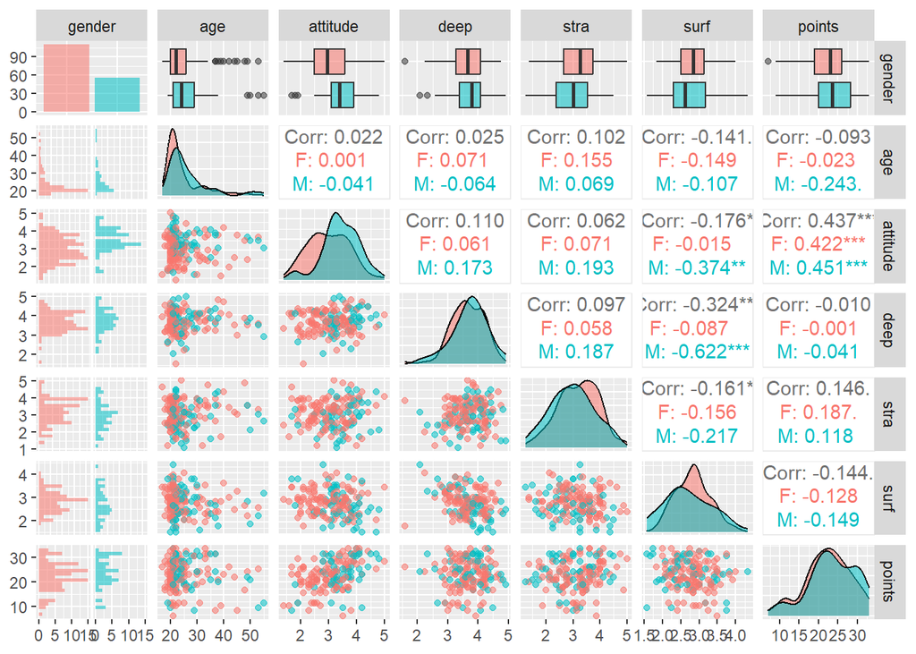

```r
# access the GGally and ggplot2 libraries
library(GGally)
library(ggplot2)

# create a plot matrix with ggpairs()
p <- ggpairs(learning2014, mapping = aes(col = gender, alpha = 0.3), lower = list(combo = wrap("facethist", bins = 20)))

# draw the plot
p
```

```r
#give a summary on the data frame
summary(learning2014)
```

```
##     gender               age           attitude          deep
##  Length:166         Min.   :17.00   Min.   :1.400   Min.   :1.583
##  Class :character   1st Qu.:21.00   1st Qu.:2.600   1st Qu.:3.333
##  Mode  :character   Median :22.00   Median :3.200   Median :3.667
##                     Mean   :25.51   Mean   :3.143   Mean   :3.680
##                     3rd Qu.:27.00   3rd Qu.:3.700   3rd Qu.:4.083
##                     Max.   :55.00   Max.   :5.000   Max.   :4.917
##       stra            surf           points
##  Min.   :1.250   Min.   :1.583   Min.   : 7.00
##  1st Qu.:2.625   1st Qu.:2.417   1st Qu.:19.00
##  Median :3.188   Median :2.833   Median :23.00
##  Mean   :3.121   Mean   :2.787   Mean   :22.72
##  3rd Qu.:3.625   3rd Qu.:3.167   3rd Qu.:27.75
##  Max.   :5.000   Max.   :4.333   Max.   :33.00
```

Studying the correlation between variables with points as a target value and the explanatory variables as the 3 highest correlation variables and comparing it to a model with only 2 explanatory variables

```r
# fit a linear multiple regression model with 3 and 2 explanatory variables
my_model3 <- lm(points ~ attitude + stra + surf, data = learning2014)
my_model2 <- lm(points ~ attitude + stra, data = learning2014)

# print out a summary of the model
summary(my_model3)
```

```
##
## Call:
## lm(formula = points ~ attitude + stra + surf, data = learning2014)
##
## Residuals:
##      Min       1Q   Median       3Q      Max
## -17.1550  -3.4346   0.5156   3.6401  10.8952
##
## Coefficients:
##             Estimate Std. Error t value Pr(>|t|)
## (Intercept)  11.0171     3.6837   2.991  0.00322 **
## attitude      3.3952     0.5741   5.913 1.93e-08 ***
## stra          0.8531     0.5416   1.575  0.11716
## surf         -0.5861     0.8014  -0.731  0.46563
## ---
## Signif. codes:  0 '***' 0.001 '**' 0.01 '*' 0.05 '.' 0.1 ' ' 1
##
## Residual standard error: 5.296 on 162 degrees of freedom
## Multiple R-squared:  0.2074, Adjusted R-squared:  0.1927
## F-statistic: 14.13 on 3 and 162 DF,  p-value: 3.156e-08
```

```r
summary(my_model2)
```

```
##
## Call:
## lm(formula = points ~ attitude + stra, data = learning2014)
##
## Residuals:
##      Min       1Q   Median       3Q      Max
## -17.6436  -3.3113   0.5575   3.7928  10.9295
##
## Coefficients:
##             Estimate Std. Error t value Pr(>|t|)
## (Intercept)   8.9729     2.3959   3.745  0.00025 ***
## attitude      3.4658     0.5652   6.132 6.31e-09 ***
## stra          0.9137     0.5345   1.709  0.08927 .
## ---
## Signif. codes:  0 '***' 0.001 '**' 0.01 '*' 0.05 '.' 0.1 ' ' 1
##
## Residual standard error: 5.289 on 163 degrees of freedom
## Multiple R-squared:  0.2048, Adjusted R-squared:  0.1951
## F-statistic: 20.99 on 2 and 163 DF,  p-value: 7.734e-09
```

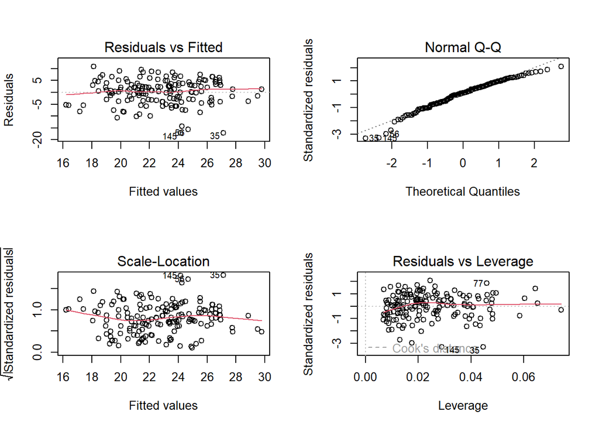

```r
# create diagnostic plots for both models to compare
par(mfrow = c(2,2))
plot(my_model3)
```

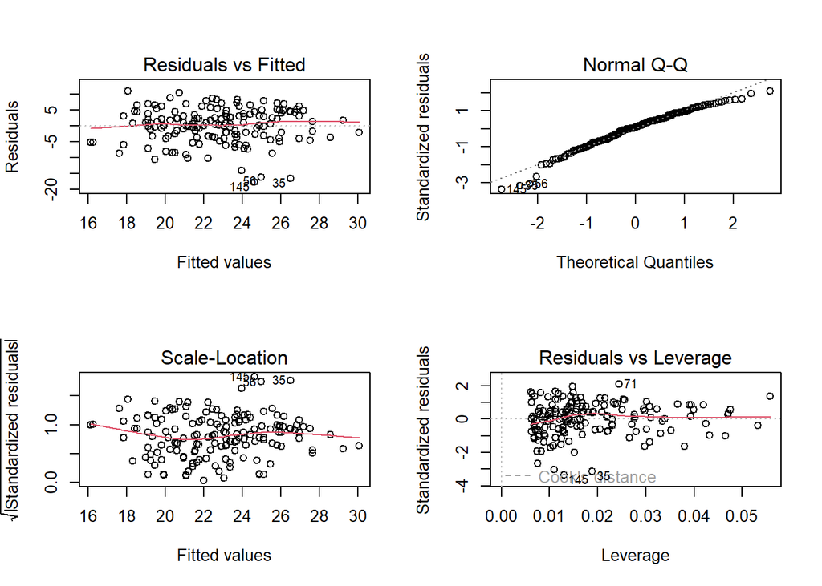

```r
par(mfrow = c(2,2))
plot(my_model2)
```

Here we test the ability for the attitude and answers to questions about strategic and surface learning together to explain exam points that the students reached. The residuals follow a Gaussian distribution quite nicely apart from the min (-17) and max (11) values. This might point to some outliers in the data skewing the model (but not necessarily). This holds true for both models with 3 and 2 explanatory factors.

The model with three factors together explaining the points did not reach a high R-squared value (0.2), i.e. the model does not seem to fit the data that well / there does not seem to be a strong link between these parameters and the exam points. The R-squared decreased ever so slightly when removing the third factor from the model, but the change is not very significant. The opposite was then true for the adjusted r-squared, but still the change is negligible.

There is no patterns visible to residual vs. fitted plots (this is good). The Q-Q plot has a slight downward curve / the points curve off in the extremities. This points to the data having more extreme values for it to properly fit the regression. From the residuals vs. leverage plots it can be seen that individual observations do not a strong influence on the coefficients in the regression model. All plots for both models are very similar.